# March 23 Updates to report

Hardy Griesbauer

23/03/2020

### Updates for technical report

Below is code and output for the technical report, as per Mike’s email March 23,2020.

NB: this code is also posted in the github repo if you want to run it for your self. Just clone the entire repo to your local drive and take it from there.

https://github.com/hgriesbauer/EP1162

NB2: Plots 16,17, 18 and 19 were omitted from the dataset for these analyses because they were not measured in 1994 or 1997.

```r
dat<-
  dat %>%
  filter(!Plot %in% c(16,17,18,19)) # remove plots 16-19 from data for further analysis

# set up diameter classes
diamClass=seq(from=7.5,to=95,by=5)
```

This means that the following analyses are based on 15 plots.

From Mike’s email:

**Figure 4a and 5 (graphs of BA over time, and BAI over time, by treatment)**

These graphs are great, and we can manage with them as is, if need be. The one tweak I would ask for if possible, is a modification to the X-axis so that the timescales are linear (i.e. - proportional scale to the time elapsed between remeasurements).

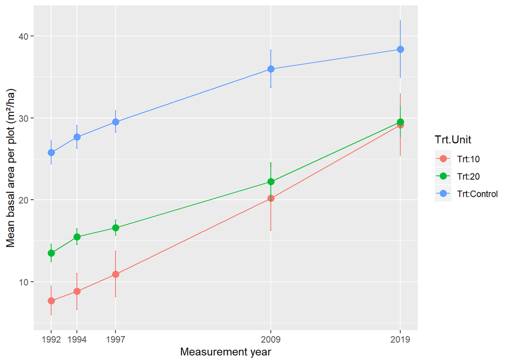

```r
dat %>%
   left_join(plotDat,by="Plot") %>% # join with plot data
  filter(Species!="Ep") %>% # remove birch
  filter(Status=="Live") %>%
  mutate(Year=as.numeric(as.character(Year))) %>%
   mutate(DBH.class=cut(DBH,diamClass,ordered_result = TRUE,right=F)) %>% # assign DBH classes
  mutate(BA=(DBH/100/2)^2*pi) %>% # convert tree DBH to basal area
  group_by(BA.Target,Plot,Year) %>%
  summarise(BA=sum(BA)*20) %>% # multiply by 20 for BA/ha
  ungroup() %>%

  # create mean and SD
  group_by(BA.Target,Year) %>%
  summarise(BA.Mean=mean(BA),
            BA.se=sd(BA)/sqrt(length(BA))) %>% # calculate standard error of the mean

    # Add labeller column
  mutate(Trt.Unit=factor(paste("Trt:",BA.Target,sep=""))) %>%

  # # padd out the year column
  # right_join(data.frame(Year=as.factor(1992:2019)),by="Year") %>%


  # Plotting
  ggplot()+
  aes(x=Year,y=BA.Mean,color=Trt.Unit,group=Trt.Unit)+
  geom_point(size=3)+
  geom_line()+
  geom_errorbar(aes(ymin=BA.Mean-BA.se,ymax=BA.Mean+BA.se),width=0.1)+
  xlab("Measurement year")+
  ylab("Mean basal area per plot (m²/ha)")+
  scale_x_continuous(limits=c(1992,2019),breaks=c(1992,1994,1997,2009,2019),
                     minor_breaks = c(1992,1994,1997,2009,2019),
                     name="Measurement year") # stretch out x-axis
```

**Figure 5**

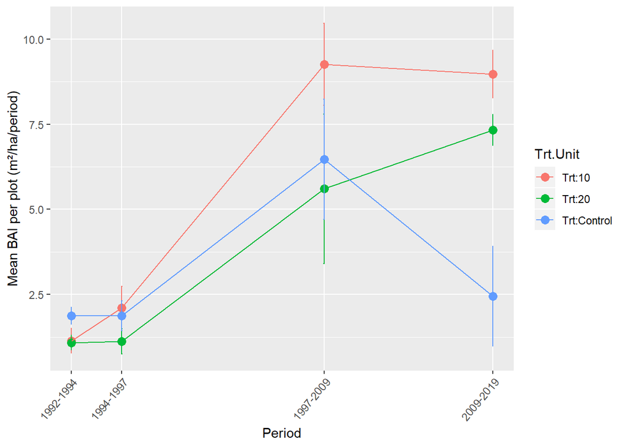

```r
dat %>%
  left_join(plotDat,by="Plot") %>% # join with plot data
   filter(Status=="Live") %>% # filter for live trees only
  mutate(BA=(DBH/2/100)^2*pi*20) %>% # convert DBH to basal area and multiply for per hectare
  dplyr::select(BA.Target,Plot,TreeID,Species,Year,BA) %>%
  group_by(BA.Target,Plot,Year) %>%
  summarise(BA.Sum=sum(BA,na.rm=T)) %>%
  pivot_wider(names_from=Year,values_from=BA.Sum) %>%
  mutate(`1992-1994`=`1994`-`1992`) %>%
  mutate(`1994-1997`=`1997`-`1994`) %>%
  mutate(`1997-2009`=`2009`-`1997`) %>%
  mutate(`2009-2019`=`2019`-`2009`) %>%

  # pivot back
  dplyr::select(BA.Target,Plot,`1992-1994`:`2009-2019`) %>%
  pivot_longer(cols=`1992-1994`:`2009-2019`,names_to="Period",values_to="PBAI") %>%
  mutate(Period=factor(Period)) %>%

  # summarise PBAI by BA.Target
  group_by(BA.Target,Period) %>%
  summarise(PBAI.mean=mean(PBAI,na.rm=T),
            PBAI.se=sd(PBAI,na.rm=T)/sqrt(length(PBAI))) %>%

    # Add labeller column
  mutate(Trt.Unit=factor(paste("Trt:",BA.Target,sep=""))) %>%

  # Add new column for plotting
  mutate(Meas.Year=str_split_fixed(Period,"-",n=2)[,2]) %>% # extract measurement year
  mutate(Meas.Year=as.numeric(Meas.Year)) %>%

  # Plotting
  ggplot()+
  aes(x=Meas.Year,y=PBAI.mean,fill=Trt.Unit,color=Trt.Unit,group=Trt.Unit)+
  geom_point(size=3)+
  geom_line()+
  geom_errorbar(aes(ymin=PBAI.mean-PBAI.se,ymax=PBAI.mean+PBAI.se),width=0.1)+
  xlab("Period")+
  ylab("Mean BAI per plot (m²/ha/period)")+
  scale_x_continuous(limits=c(1994,2019),breaks=c(1994,1997,2009,2019),
                     labels = c("1992-1994","1994-1997","1997-2009","2009-2019"),
                     name="Period",
                     minor_breaks = c(1994,1997,2009,2019))+ # stretch out x-axis
  theme(axis.text.x = element_text(angle = 50, hjust = 1))
```

**Figure 4b (NEW) - graph of live BA over time for each of the PSP’s**

Could you please generate a graph of live BA over time for each of the PSP’s, so their collective trajectories and similarities / differences can be compared by the reader? The behaviour of the BA of individual plots varies somewhat from the treatment means, esp in the first few years, when some plots experience mortality, and others not so much.

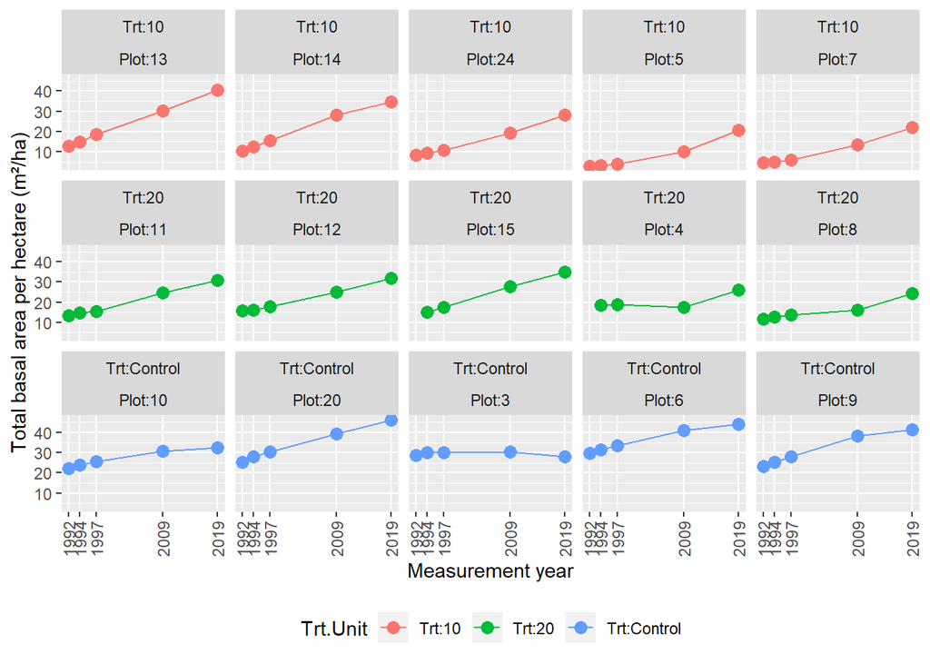

```r
dat %>%
   left_join(plotDat,by="Plot") %>% # join with plot data
  filter(Status=="Live") %>%
  mutate(Plot=paste("Plot:",Plot,sep="")) %>%
  mutate(Year=as.numeric(as.character(Year))) %>%
   mutate(DBH.class=cut(DBH,diamClass,ordered_result = TRUE,right=F)) %>% # assign DBH classes
  mutate(BA=(DBH/100/2)^2*pi) %>% # convert tree DBH to basal area
 mutate(Trt.Unit=factor(paste("Trt:",BA.Target,sep=""))) %>%
  group_by(Trt.Unit,Plot,Year) %>%
  summarise(BA=sum(BA)*20) %>% # multiply by 20 for BA/ha


  # Plotting
  ggplot()+
  aes(x=Year,y=BA,color=Trt.Unit,group=Trt.Unit)+
  geom_point(size=3)+
  geom_line()+
  ylab("Total basal area per hectare (m²/ha)")+
  scale_x_continuous(limits=c(1992,2019),breaks=c(1992,1994,1997,2009,2019),
                     minor_breaks = c(1992,1994,1997,2009,2019),
                     name="Measurement year")+ # stretch out x-axis
  facet_wrap(Trt.Unit~Plot,ncol=5)+
  theme(axis.text.x = element_text(angle = 90, hjust = 1,vjust=0.5),
        legend.position = "bottom")
```

**Updated Figure 4b - All PSPs on one graph**

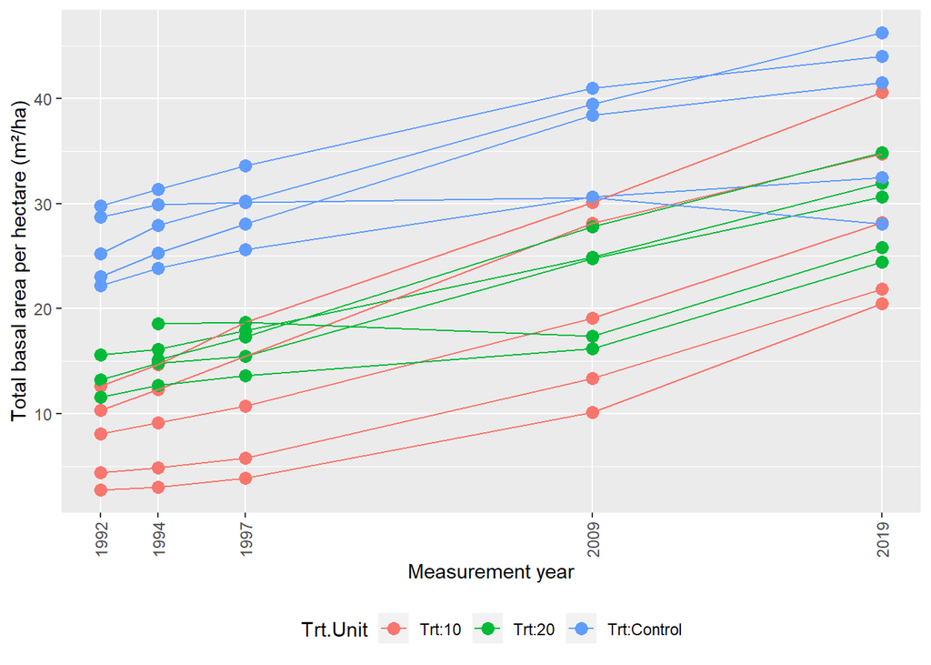

```r
dat %>%
   left_join(plotDat,by="Plot") %>% # join with plot data
  filter(Status=="Live") %>%
  mutate(Plot=paste("Plot:",Plot,sep="")) %>%
  mutate(Year=as.numeric(as.character(Year))) %>%
   mutate(DBH.class=cut(DBH,diamClass,ordered_result = TRUE,right=F)) %>% # assign DBH classes
  mutate(BA=(DBH/100/2)^2*pi) %>% # convert tree DBH to basal area
 mutate(Trt.Unit=factor(paste("Trt:",BA.Target,sep=""))) %>%
  group_by(Trt.Unit,Plot,Year) %>%
  summarise(BA=sum(BA)*20) %>% # multiply by 20 for BA/ha


  # Plotting
  ggplot()+
  aes(x=Year,y=BA,color=Trt.Unit,group=Plot)+
  geom_point(size=3)+
  geom_line()+
  ylab("Total basal area per hectare (m²/ha)")+
  scale_x_continuous(limits=c(1992,2019),breaks=c(1992,1994,1997,2009,2019),
                     minor_breaks = c(1992,1994,1997,2009,2019),
                     name="Measurement year")+ # stretch out x-axis
  theme(axis.text.x = element_text(angle = 90, hjust = 1,vjust=0.5),
        legend.position = "bottom")
```

**Table 4 (NEW) - table(s) comparing Bl, Sx, and Fd basal area by treatment, for the years 1994 and 2019**

I would like to reference this data, to highlight quantitative changes in Bl / Sx abundance over time, by treatment, for two reference dates.

We discuss this qualitatively in reference to the graphs, but it would be good to cite specific quantitative data too.

```r
# Create a matrix with number of plots (for calculating average BA)
table4.Numplots<-
    dat %>%
   left_join(plotDat,by="Plot") %>% # join with plot data
  filter(Status=="Live") %>%
  filter(Species!="Ep") %>% # remove birch from dataset
  mutate(Year=as.numeric(as.character(Year))) %>%
  filter(Year %in% c(1994,2019)) %>%
  mutate(Trt.Unit=factor(paste("Trt:",BA.Target,sep=""))) %>%
  group_by(Trt.Unit,Year,Plot) %>%
  summarise(BA=mean(DBH)) %>%
  group_by(Trt.Unit,Year) %>%
  summarise(num.plots=n())


table4<-
  dat %>%
  left_join(plotDat,by="Plot") %>% # join with plot data
  filter(Status=="Live") %>%
  filter(Species!="Ep") %>% # remove birch from dataset
  mutate(Year=as.numeric(as.character(Year))) %>%
  filter(Year %in% c(1994,2019)) %>%
  mutate(BA=(DBH/100/2)^2*pi) %>% # convert tree DBH to basal area
  mutate(Trt.Unit=factor(paste("Trt:",BA.Target,sep=""))) %>%
  group_by(Trt.Unit,Species,Year) %>%
  summarise(BA=sum(BA,na.rm=TRUE)) %>% # summarise BA for each treatment unit/year combination
  mutate(BA=BA*20) %>% # multiply by 20 to get per hectare

  # join with number of plots
  left_join(table4.Numplots,by=c("Trt.Unit","Year")) %>%
  mutate(BA.ha=BA/num.plots) %>% # divide by number of plots to get mean BA by plot


  # remove columns for reshaping
  dplyr::select(-BA,-num.plots) %>%

  # pivot wider
  pivot_wider(names_from="Year",values_from="BA.ha")

# Print to screen
  knitr::kable(table4,format="markdown",digits=2)
```

| Trt.Unit | Species | 1994 | 2019 |
| --- | --- | --- | --- |
| Trt:10 | Bl | 5.80 | 17.27 |
| Trt:10 | Sx | 3.02 | 11.89 |
| Trt:20 | Bl | 8.39 | 17.96 |
| Trt:20 | Fd | 1.08 | 1.41 |
| Trt:20 | Sx | 6.02 | 10.16 |
| Trt:Control | Bl | 17.45 | 26.87 |
| Trt:Control | Sx | 10.21 | 11.54 |

```r
# write to .csv
  write.csv(table4,file="table4.csv")
```

Table shows mean BA per plot, multiplied by 20 to get BA/ha.

Note: this code also writes Table 4 to a .csv, so you can adjust formatting to fit the paper.

**Figure 8 (QUESTIONS) - changes over time in trees species comp and distribution by BA**

The Trt20 basal areas for 2019 seem higher than they do in Figure 4a. In Figure 4a, Trt10 and Trt20 BA values converge and are almost identical. Are we comparing apples to apples (i.e. live basal area) for both Figures 4a and 8?

*From Hardy* Good catch! There was a mathematical issue with how the mean BA per plot per species was being calculated. I’ve fixed it in the code below.

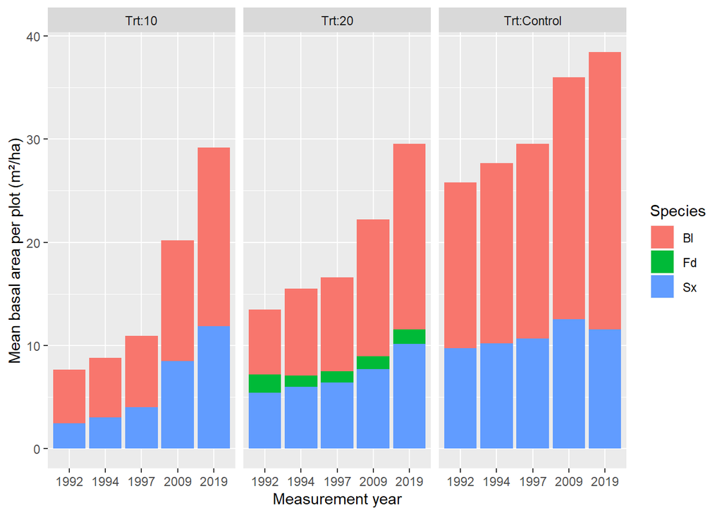

```r
dat %>%
    filter(Species!="Ep") %>% # remove birch
    filter(Status=="Live") %>% # filter for live only trees
   left_join(plotDat,by="Plot") %>% # join with plot data
   mutate(DBH.class=cut(DBH,diamClass,ordered_result = TRUE,right=F)) %>% # assign DBH classes
  mutate(BA=(DBH/100/2)^2*pi) %>% # convert tree DBH to basal area
  group_by(BA.Target,Plot,Year,Species) %>%
  summarise(BA=sum(BA)*20) %>% # multiply by 20 for BA/ha
  ungroup() %>%

  # have to assign plots missing species with BA=0
  pivot_wider(names_from="Species",values_from="BA") %>%
  mutate_at(vars(c("Sx","Fd")),replace_na,0) %>%
  pivot_longer(cols=Bl:Fd,names_to="Species",values_to="BA") %>%

  # create mean and SD
  group_by(BA.Target,Year,Species) %>%
  summarise(BA.Mean=mean(BA),
            BA.se=sd(BA)/sqrt(length(BA))) %>% # calculate standard error of the mean

    # Add labeller column
  mutate(label=factor(paste("Trt:",BA.Target,sep=""))) %>%

  # # pad out the year column
  # right_join(data.frame(Year=as.factor(1992:2019)),by="Year") %>%

  # Plotting
  ggplot()+
  aes(x=Year,y=BA.Mean,fill=Species)+
  geom_bar(stat="Identity")+
  facet_wrap(~label)+
  ylab("Mean basal area per plot (m²/ha)")+
  xlab("Measurement year")
```

**NB** Note the decrease in Fd basal area per plot between 1992 and 1994. This is due to how I calculated these graphs (mean BA per plot), and the different number of plots between 1992 and 1994. This is not because of Fd mortality (as this figure might imply). I see a couple of options:

1. Explain this in the report; or
2. Limit analysis for these types of figures to 1994-2019 period; or
3. Come up with a different method to calculate BA by period (open to suggestions!).

Might be other options too.

**Which plots have live Fd stems in them, and how many stems are they?**

I am guessing that the significant Fd basal area in Figure 8 is due to few stems.

```r
dat %>% filter(Species=="Fd")
```

```
## # A tibble: 5 x 19
##   Plot  TreeID Species Sector Year  Status   DBH Height Comments  Conk
##   <chr> <chr>  <fct>   <fct>  <fct> <fct>  <dbl>  <dbl> <chr>    <dbl>
## 1 12    49     Fd      3      1992  Live    58.1   35.1 LAB         NA
## 2 12    49     Fd      3      1994  Live    58.5   36.4 <NA>        NA
## 3 12    49     Fd      3      1997  Live    59.6   NA   <NA>        NA
## 4 12    49     Fd      3      2009  Live    64     NA   Live        NA
## 5 12    49     Fd      3      2019  Live    67.1   36.1 <NA>        NA
## # ... with 9 more variables: BlindConk <lgl>, Scar <dbl>,
## #   Fork.Crook <dbl>, Frost.Crack <dbl>, Mistletoe <lgl>, R.Branch <lgl>,
## #   DBT <dbl>, Crown.Class <dbl>, L.Crown <dbl>
```

There is only one (albeit large) Fd tree in the entire dataset (note that there may be Fd in plots 16-19, which are not included in this analysis).

**Figure 7 (QUESTION) - total sph by dbh class - diameter distribution over time**

You mentioned that we see a drop in sph of the smaller diameter classes between 1992 and 1994, and we attribute this to mortality processes. This is vaguely apparent in the graphs, but at a small scale. Could you please generate a table of sph numbers by dbh class for 1992 and 1994 for each treatment, that would allow us to address our comments more quantitatively and less qualitatively?

```r
sphCount<-
dat %>%
    filter(Species!="Ep") %>% # remove birch
  filter(Year %in% c(1992,1994)) %>%
    filter(Status=="Live") %>% # filter for live only trees
   left_join(plotDat,by="Plot") %>% # join with plot data
   mutate(DBH.class=cut(DBH,diamClass,ordered_result = TRUE,right=F)) %>% # assign DBH classes
  group_by(BA.Target,Plot,Year,Species,DBH.class) %>%
  summarise(Num.Trees=n()) %>%
  ungroup() %>%
  group_by(BA.Target,Year,Species,DBH.class) %>%
    summarise(Num.Trees=mean(Num.Trees)*20) %>% # multiply by 20 to get per hectare
  pivot_wider(names_from="Year",values_from = "Num.Trees") %>%
arrange(BA.Target,Species,DBH.class)

# Print table to screen
knitr::kable(sphCount,digits=2)
```

| BA.Target | Species | DBH.class | 1992 | 1994 |
| --- | --- | --- | --- | --- |
| 10 | Bl | [7.5,12.5) | 100.00 | 80.00 |
| 10 | Bl | [12.5,17.5) | 55.00 | 56.00 |
| 10 | Bl | [17.5,22.5) | 46.67 | 26.67 |
| 10 | Bl | [22.5,27.5) | 20.00 | 40.00 |
| 10 | Bl | [27.5,32.5) | 40.00 | 30.00 |
| 10 | Bl | [32.5,37.5) | 30.00 | 40.00 |
| 10 | Bl | [37.5,42.5) | 20.00 | 20.00 |
| 10 | Sx | [7.5,12.5) | 100.00 | 113.33 |
| 10 | Sx | [12.5,17.5) | 40.00 | 60.00 |
| 10 | Sx | [17.5,22.5) | 33.33 | 20.00 |
| 10 | Sx | [22.5,27.5) | 40.00 | 46.67 |
| 10 | Sx | [32.5,37.5) | 20.00 | NA |
| 10 | Sx | [37.5,42.5) | NA | 20.00 |
| 20 | Bl | [7.5,12.5) | 273.33 | 208.00 |
| 20 | Bl | [12.5,17.5) | 93.33 | 124.00 |
| 20 | Bl | [17.5,22.5) | 40.00 | 60.00 |
| 20 | Bl | [22.5,27.5) | 20.00 | 30.00 |
| 20 | Bl | [27.5,32.5) | 20.00 | 35.00 |
| 20 | Fd | [57.5,62.5) | 20.00 | 20.00 |
| 20 | Sx | [7.5,12.5) | 20.00 | 20.00 |
| 20 | Sx | [12.5,17.5) | 30.00 | 30.00 |
| 20 | Sx | [17.5,22.5) | 40.00 | 30.00 |
| 20 | Sx | [22.5,27.5) | 30.00 | 40.00 |
| 20 | Sx | [27.5,32.5) | 40.00 | 40.00 |
| 20 | Sx | [32.5,37.5) | NA | 20.00 |
| 20 | Sx | [37.5,42.5) | 20.00 | 25.00 |
| Control | Bl | [7.5,12.5) | 368.00 | 364.00 |
| Control | Bl | [12.5,17.5) | 212.00 | 216.00 |
| Control | Bl | [17.5,22.5) | 160.00 | 160.00 |
| Control | Bl | [22.5,27.5) | 44.00 | 60.00 |
| Control | Bl | [27.5,32.5) | 40.00 | 33.33 |
| Control | Bl | [32.5,37.5) | 26.67 | 26.67 |
| Control | Sx | [7.5,12.5) | 120.00 | 40.00 |
| Control | Sx | [12.5,17.5) | 33.33 | 46.67 |
| Control | Sx | [17.5,22.5) | 30.00 | 40.00 |
| Control | Sx | [22.5,27.5) | 20.00 | 20.00 |
| Control | Sx | [27.5,32.5) | 20.00 | 20.00 |
| Control | Sx | [32.5,37.5) | 26.67 | 33.33 |
| Control | Sx | [37.5,42.5) | 30.00 | 25.00 |
| Control | Sx | [42.5,47.5) | 20.00 | 20.00 |
| Control | Sx | [47.5,52.5) | 20.00 | 20.00 |

```r
# write to csv
write.csv(sphCount,file="tableForFigure7.csv")
```

*This plot shows the mean number of stems per hectare plot per Treatment Unit/Species/DBH Class/Year*

Would this sort of table work? I think a lot of the differences between 1992 and 1994 might be in the difference in plots measured between 1992 and 1994.

Note the funny formatting in the DBH class actually has a purpose: the ‘[’ denotes the lower value that is contained within the DBH class, and the ‘)’ denotes the upper value that forms the lower bound of the next higher class. In other words, in the [7.5-12.5) class, a tree that measured 12.5 would be included in the next higher class (i.e., [12.5-17.5)).